# Data science in the Humanities

Big data-Analysis of phonetic data

Peter Gilles

29. April 2020, 14h00 - 15h00, University of Luxembourg

# Preamble

This is an [R Markdown](http://rmarkdown.rstudio.com) Notebook. When you execute code within the notebook, the results appear beneath the code. In order to do so, you need to have R and RStudio installed. When this R notebook is loaded into RStudio, you can excecute chunks by clicking the *Run* button within the chunk or by placing your cursor inside it and pressing *Cmd+Shift+Enter*, allowing you to experiment with the code. This handout contains all output of the code (tables, visualisations etc.).

The following libraries will be needed and have to be installed.

```r
library(tidyverse)
```

```r
library(ggiraph)
library(cowplot)
library(emuR)
library(tools)
library(rio)
library(ggplot2)
library(magrittr)
library(ggiraph)
library(htmltools)
library(shiny)
library(joeyr, warn.conflicts = FALSE )
library(knitr)
```

This tutorial will demonstrate how to analyse audio data for phonetic studies in R. Topics covered are: - phonetic databases, the case of emuR and EMU-SDMS - provide a sample data base (subset of the LOD database) - present the LOD database - do queries requeries - serve() - overview of the database segments, categories - calculate duration - vowels formants - Pillai distance

# LOD database

```r
db = load_emuDB("/Users/peter.gilles/Documents/_Daten/LOD-emuDB/lod_emuDB")
```

```
## INFO: Checking if cache needs update for 1 sessions and 26093 bundles ...
## INFO: Performing precheck and calculating checksums (== MD5 sums) for _annot.json files ...
## INFO: Nothing to update!
```

```r
summary(db)
```

```
## Name:     lod
## UUID:     c87793c0-012a-11e9-874b-68b599b5deb4
## Directory:    /Users/peter.gilles/Documents/_Daten/LOD-emuDB/lod_emuDB
## Session count: 1
## Bundle count: 26093
## Annotation item count:  515638
## Label count:  639542
## Link count:  489545
##
## Database configuration:
##
## SSFF track definitions:
##       name columnName fileExtension
## 1      dft        dft           dft
## 2 praatFms         fm      praatFms
##
## Level definitions:
##     name    type nrOfAttrDefs              attrDefNames
## 1 bundle    ITEM            4 bundle; source; SAM; MAO;
## 2    ORT    ITEM            2                 ORT; KAN;
## 3    MAU SEGMENT            1                      MAU;
##
## Link definitions:
##          type superlevelName sublevelName
## 1 ONE_TO_MANY         bundle          ORT
## 2 ONE_TO_MANY            ORT          MAU
```

```r
list_ssffTrackDefinitions(db)
```

```
##       name columnName fileExtension
## 1      dft        dft           dft
## 2 praatFms         fm      praatFms
```

```r
list_attrDefLabelGroups(db, "MAU", "MAU")
```

```
##                name                           values
## 1  longMonophthongs       iː; uː; aː; oː; ɔː; ɛː; eː
## 2 shortMonophthongs           i; u; ɑ; o; æ; e; ə; ɐ
## 3        Diphthongs iə; uə; ɑɪ; ɑʊ; əʊ; ɜɪ; æːɪ; æːʊ
```

# Database queries

An emuR database can be queried with a powerful query engine. The first example is a simple query for one word, `Aarbecht`.

```r
sl = query(db, query = "[ ORT == 'Aarbecht']")
sl
```

```
## # A tibble: 1 x 16
##   labels start   end db_uuid session bundle start_item_id end_item_id level
##   <chr>  <dbl> <dbl> <chr>   <chr>   <chr>          <int>       <int> <chr>
## 1 Aarbe…  130.  680. c87793… 0000    AARBE…             1           1 ORT
## # … with 7 more variables: attribute <chr>, start_item_seq_idx <int>,
## #   end_item_seq_idx <int>, type <chr>, sample_start <int>, sample_end <int>,
## #   sample_rate <int>
```

The result is a `segment list` (`sl`), containing various information about the found item (time, level, name, database info). The result of the query can also be displayed in the EMU Speech Database Management System. Use: `serve(db, seglist = sl)`. The GUI will open in the `Viewer` pane of RStudio or you can open it in a browser (Chrome preferred).

[figure not shown]

Here we can also display the hiearchical structure for this database item, which is accessed during queries. `bundle` is the top-level, representing the entire audio file. The `ORT` level contains the nodes for the individual words in the `bundle`, here the two words `Aarbecht` and `Aarbechten`. The dependend level then is `MAU` (=`Munich Automatic Unit`) representing the single sounds of the words in `ORT`.

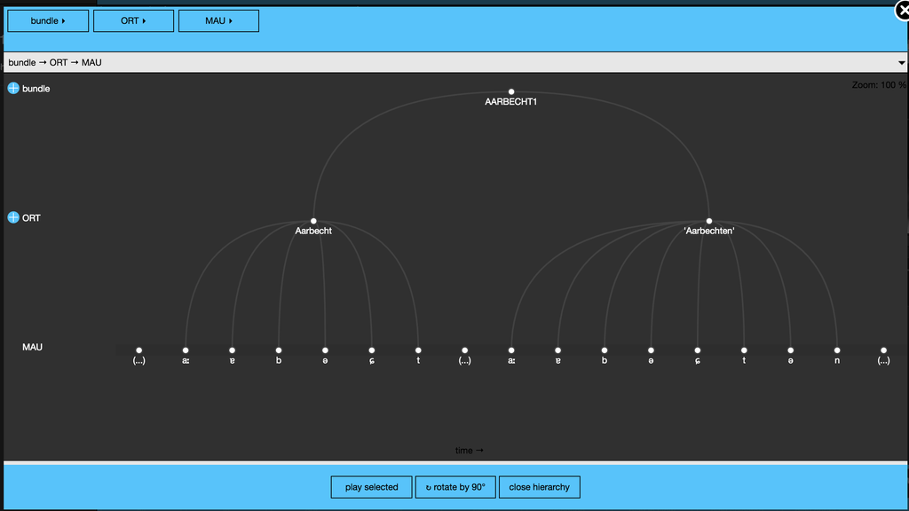

Two aspects render emuR query system extremly powerful: the use of regular expressions (including negation and other extensions) and the combinated query on different levels of the database.

Some more complex queries:

- regular expression, operator `=~`, words beginning with `Aarbecht...`

```r
sl = query(db, query = "[ ORT =~ 'Aarbecht.*']")
sl
```

```
## # A tibble: 41 x 16
##    labels start   end db_uuid session bundle start_item_id end_item_id level
##    <chr>  <dbl> <dbl> <chr>   <chr>   <chr>          <int>       <int> <chr>
##  1 Aarbe…  130.  680. c87793… 0000    AARBE…             1           1 ORT
##  2 Aarbe…  120.  840. c87793… 0000    AARBE…             1           1 ORT
##  3 Aarbe…  120. 1120. c87793… 0000    AARBE…             1           1 ORT
##  4 Aarbe… 3350. 4540. c87793… 0000    AARBE…             3           3 ORT
##  5 Aarbe…  120.  960. c87793… 0000    AARBE…             1           1 ORT
##  6 Aarbe…  130. 1040. c87793… 0000    AARBE…             1           1 ORT
##  7 Aarbe…  130. 1230. c87793… 0000    AARBE…             1           1 ORT
##  8 Aarbe…  120.  970. c87793… 0000    AARBE…             1           1 ORT
##  9 Aarbe…  130. 1290. c87793… 0000    AARBE…             1           1 ORT
## 10 Aarbe…  120. 1300. c87793… 0000    AARBE…             1           1 ORT
## # … with 31 more rows, and 7 more variables: attribute <chr>,
## #   start_item_seq_idx <int>, end_item_seq_idx <int>, type <chr>,
## #   sample_start <int>, sample_end <int>, sample_rate <int>
```

# Vowel explorer

```r
knitr::include_app("https://petergill.shinyapps.io/shinyplay/")
```

[interactive chart not shown]

# Calculate the Pillai distance